# Run the cell below to generate the road map (do not modify it)

#### Question 21

Is using K-Means the best choice for a clustering algorithm? Comment the choice and suggest alternatives. For example, look at [Mixture Models](https://en.wikipedia.org/wiki/Mixture_model) and, if you have time, propose an alternative clustering technique.

**NOTE**: Mixture models will be covered in the ASI course in greater detail.

```python
from pyspark.mllib.clustering import GaussianMixtureModel, GaussianMixture

k_val = ks[1]

GMmodel = GaussianMixture.train(filtered_data, k_val, convergenceTol=0.0001, maxIterations=50, seed=10)
GMlabels = GMmodel.predict(filtered_data)
```

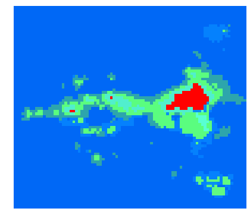

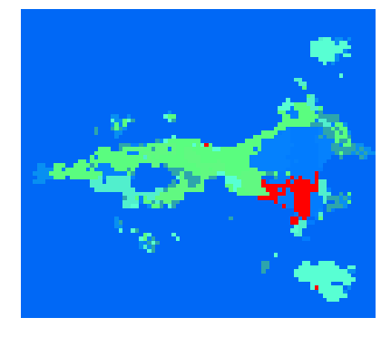

```python
KMimage = draw_filtered_labels(data, KMlabels)
GMimage = draw_filtered_labels(data, GMlabels.collect())
```

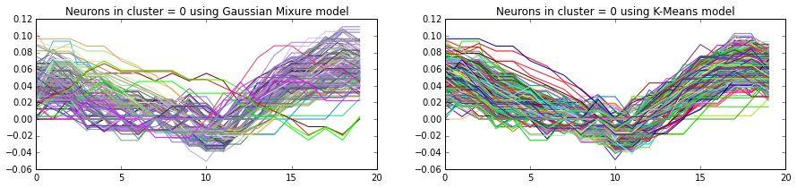

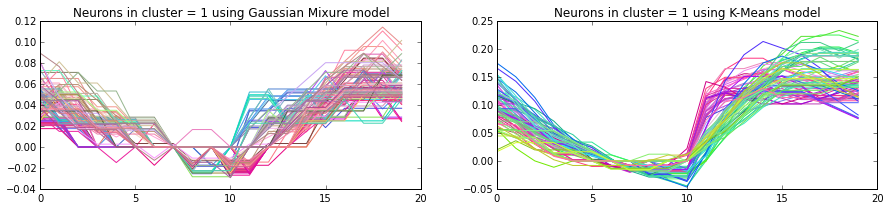

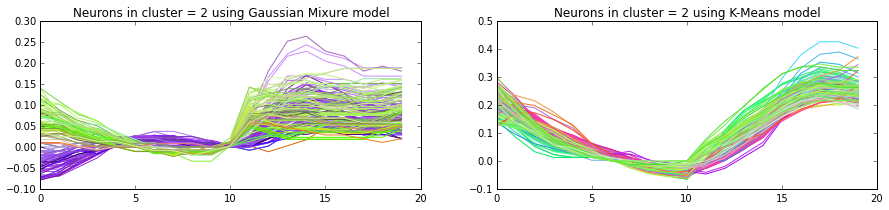

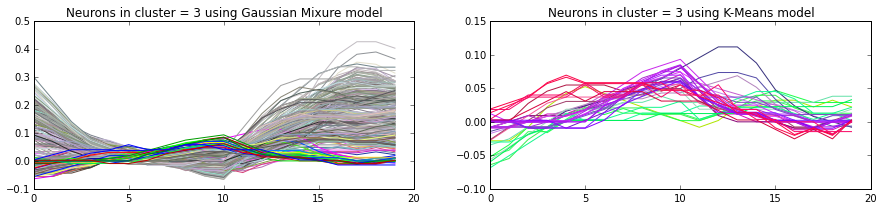

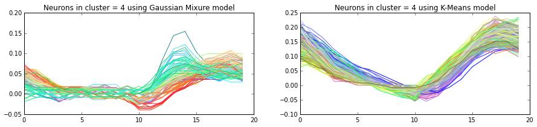

```python
GMdata_label = filtered_data.zip(GMlabels)
KMdata_label = filtered_data.zip(KMlabels)


for i in range(5):
    plt.figure(figsize=(15,3))
    data_to_plot = GMdata_label.filter(lambda x: x[1] == i).map(lambda x: x[0]).collect()

    plt.subplot(1, 2, 1)
    newClrs = optimize_color(data_to_plot)
    plt.gca().set_color_cycle(newClrs.colors)
    plt.title("Neurons in cluster = "+str(i)+" using Gaussian Mixure model")
    plt.plot(np.array(data_to_plot).T);


    data_to_plot = KMdata_label.filter(lambda x: x[1] == i).map(lambda x: x[0]).collect()

    plt.subplot(1, 2, 2)
    newClrs = optimize_color(data_to_plot)
    plt.gca().set_color_cycle(newClrs.colors)
    plt.title("Neurons in cluster = "+str(i)+" using K-Means model")
    plt.plot(np.array(data_to_plot).T);

    plt.show()
```

Since we didn't found a common way to measure the quality of this two models what we tried to do is to have a graphic representation of the data inside a cluster. We plotted 5 generic clusters of both the methods, here giving a coarse description of those results we can see that the Gaussian Mixture model using the same number of k (that might is not a great idea) gives us worse results, indeed the K means curves in each cluster seems to have a more similar shape.

# 4. Summary

We studied Thunder and its important methods to work with images, such as `Image`, `Series` and how to apply them to a use case. In the use case, we used the K-Means algorithm to cluster the neurons without prior knowledge of what a good choice of K could be. Subsequently, we introduced some techniques for improving the initially obtained results, such as removing noise and considering similarity.

# References

Some of the examples in this notebook are inspired from the [documentation of Thunder](http://docs.thunder-project.org/).